# DDK Modelling spatial variability

# 1 Summary

In this analysis we model the spatial variability of /pa/, /ta/, and /ka/ repetitions in a DDK task. In order to do so, for each repetition, we measured the location of the primary articulator during the maximal constriction of the gesture (/p/, /t/, or /k/). We then calculated Euclidean distance between each individual location and the mean location of the trial in question. After doing so, we calculated the standard deviation over those distances for each trial. The result is our *temp_var* dependent variable.

[figure not shown]

# 2 List of factors

| Factor | Description |
| --- | --- |
| **dist2centroid** | the euclidean distance between the sensor position at MAXC (target) position and the mean sensor position at MAXC over that trial |
| **gest.dur** | the duration of the entire gesture from GONS to GOFFS |
| **dist2target** | the Euclidean distance between the sensor position at GONS and MAXC |
| **time2target** | the duration between GONS and MAXC |
| **speed2target** | displacement over duration for the GONS to MAXC interval (dist2target/time2target) |
| **peakvel2target** | the peak velocity towards the target of the current gesture |
| **stiffness2target** | the stiffness2target of the current gesture (peakvel2target/displacement) of the current gesture |
| **seg** | segment: /p/, /t/, or /k/ |
| **rep.no** | repetition number within the trial, ranging from 1 to 10 |
| **trial.no** | trial number in the experiment |
| **prop.dur** | relative position of GOFFS in the entire interval from GONS to the next GONS |
| **pace** | repetition frequency |

## 2.1 Load packages

```r
library("mgcv")
library("itsadug")
library("visreg")
library("dplyr")
```

```r
library("ggcorrplot")
```

# 3 Load data

```r
setwd("C:/Users/45598770/Desktop/analyse")
df <- readRDS("modelling_data_DDK.rds")

df$seg <- relevel(df$seg, "P")
```

Get rid of outlier:

```r
#df <- df %>% subset(!subj == "PD09")
```

Get rid of duplicate rows and sort data:

```r
df <- df %>% distinct(temp_var, spat_var_bivariate, subj, trial.no, mean.syl.dur, mean.speed2target, mean.gest.dur, group, mean.time2target, mean.dist2target, mean.stiffness2target, mean.peakvel2target, mean.time.between.targets, mean.dur.accphase, mean.dur.decphase, pace, block, gender, age, dialect, seg, gesture.type, diagnosis, total_UPDRS, motor_UPDRS, tremor, akinetic)
df <- df[order(df$subj, df$trial),]
```

Create ordered factors:

```r
df$groupO <- as.ordered(df$group)
contrasts(df$groupO) <-"contr.treatment"

df$typicalP_O <- as.ordered(with(df, ifelse(seg=="P" & group == "typical", 1, 0)))
contrasts(df$typicalP_O) <-"contr.treatment"

df$typicalTK_O <- as.ordered(with(df, ifelse((seg=="T" & group == "typical")|(seg=="K" & group == "typical"), 1, 0)))
contrasts(df$typicalTK_O) <-"contr.treatment"

df$typicalK_O <- as.ordered(with(df, ifelse(seg=="K" & group == "typical", 1, 0)))
contrasts(df$typicalK_O) <-"contr.treatment"

df$segO <- as.ordered(df$seg)
contrasts(df$segO) <-"contr.treatment"

df$gesture.typeO <- as.ordered(df$gesture.type)
contrasts(df$gesture.typeO) <-"contr.treatment"

df$segTK <- as.ordered(with(df, ifelse(seg=="T"|seg=="K", 1, 0)))
contrasts(df$segTK) <-"contr.treatment"

df$segT <- as.ordered(with(df, ifelse(seg=="T", 1, 0)))
contrasts(df$segT) <-"contr.treatment"

df$typicalLingualO <- as.ordered(with(df, ifelse(gesture.type=="lingual" & group == "typical", 1, 0)))
contrasts(df$typicalLingualO) <-"contr.treatment"
```

Create binary predictors to check interactions:

```r
df$IsPD <- with(df,  ifelse(group=="PD", 1, 0)) # create binary predictor
```

# 4 Checks

Examine correlations:

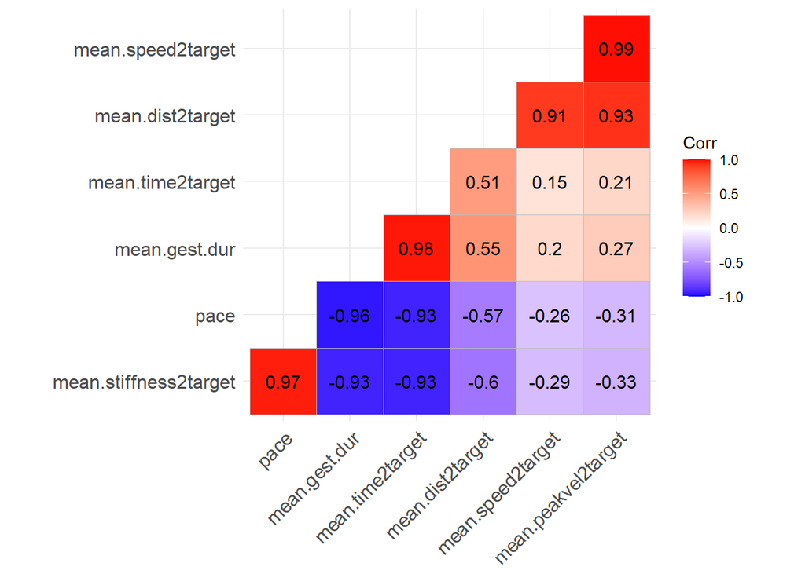

```r
dfcor <- df %>% select(mean.speed2target, mean.gest.dur,  mean.peakvel2target,mean.time2target, mean.dist2target, mean.stiffness2target, pace)
r <- cor(dfcor, use="complete.obs")

ggcorrplot(r,
           hc.order = TRUE,
           type = "lower",
           lab = TRUE)
```

Some plots:

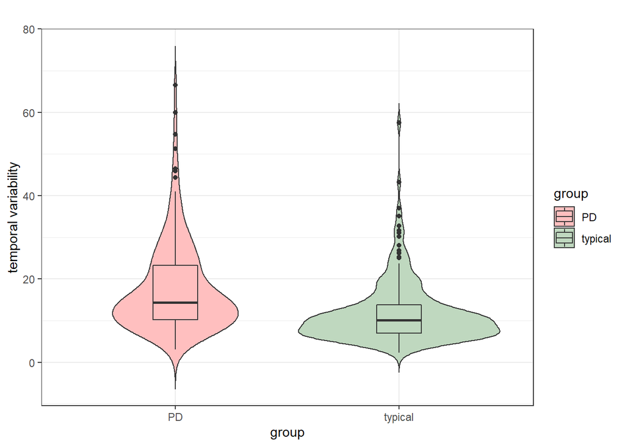

```r
dodge = .5
dodge <- position_dodge(width = 0.9)
ggplot(df, aes(x=group, y=temp_var, fill=group)) + geom_violin(trim=FALSE) + labs(title = "", y = "temporal variability") + geom_boxplot(width=.2, position = dodge) + scale_fill_manual(values=c("#ffbfbf", "#bfd8bf")) + theme_bw()
```

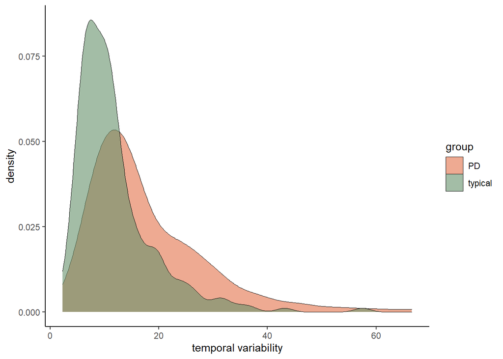

```r
ggplot(df, aes(x=temp_var, fill = group)) +
  geom_density(size = 0, alpha=0.6) + theme_classic() +labs(x="temporal variability") + scale_fill_manual(values=c("#e37249", "#66916a"))
```

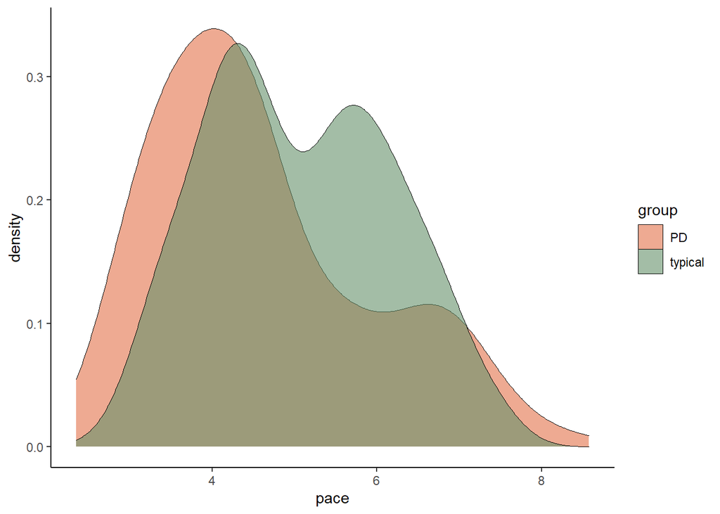

```r
ggplot(df, aes(x=pace, fill = group)) +
  geom_density(size = 0, alpha=0.6) + theme_classic() + labs(x="pace") + scale_fill_manual(values=c("#e37249", "#66916a"))
```

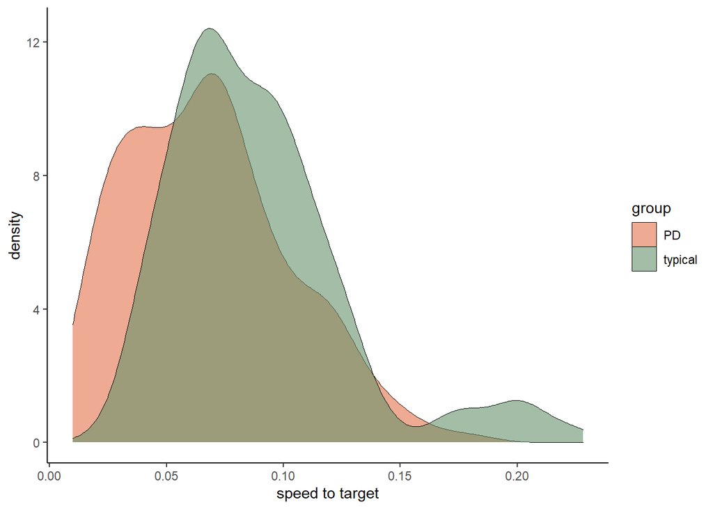

```r
ggplot(df, aes(x=mean.speed2target, fill = group)) +
  geom_density(size = 0, alpha=0.6) +labs(x="speed to target") + theme_classic() + scale_fill_manual(values=c("#e37249", "#66916a"))
```

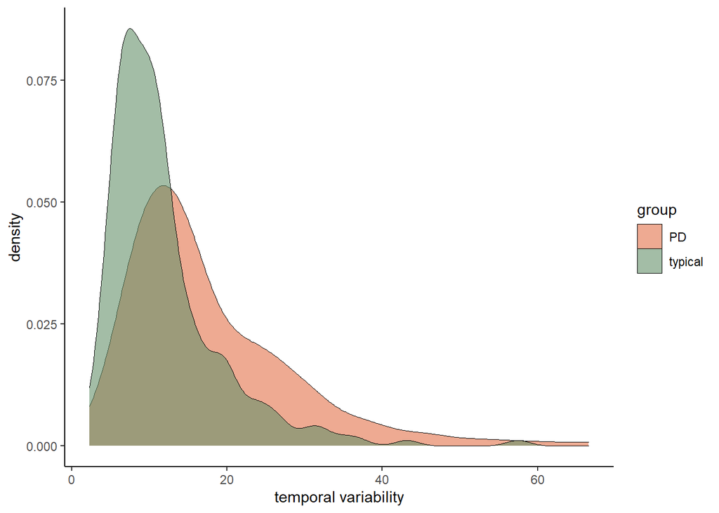

```r
ggplot(df, aes(x=temp_var, fill = group)) +
  geom_density(size = 0, alpha=0.6) + theme_classic() +labs(x="temporal variability") + scale_fill_manual(values=c("#e37249", "#66916a"))
```

# 5 Hypothesis testing

First model

```r
summary(m0 <- bam(temp_var ~ s(subj,bs='re'), data = df, method = "ML"))
```

```
##
## Family: gaussian
## Link function: identity
##
## Formula:
## temp_var ~ s(subj, bs = "re")
##
## Parametric coefficients:
##             Estimate Std. Error t value Pr(>|t|)
## (Intercept)   15.174      1.086   13.97   <2e-16 ***
## ---
## Signif. codes:  0 '***' 0.001 '**' 0.01 '*' 0.05 '.' 0.1 ' ' 1
##
## Approximate significance of smooth terms:
##          edf Ref.df     F p-value
## s(subj) 34.8     41 5.331  <2e-16 ***
## ---
## Signif. codes:  0 '***' 0.001 '**' 0.01 '*' 0.05 '.' 0.1 ' ' 1
##
## R-sq.(adj) =  0.357   Deviance explained = 41.3%
## -ML = 1415.6  Scale est. = 59.344    n = 397
```

Add group?

```r
summary(m1 <- bam(temp_var ~ groupO + s(subj,bs='re'), data = df, method = "ML"))
```

```
##
## Family: gaussian
## Link function: identity
##
## Formula:
## temp_var ~ groupO + s(subj, bs = "re")
##
## Parametric coefficients:
##               Estimate Std. Error t value Pr(>|t|)
## (Intercept)     18.761      1.380  13.593  < 2e-16 ***
## groupOtypical   -6.779      1.877  -3.612 0.000346 ***
## ---
## Signif. codes:  0 '***' 0.001 '**' 0.01 '*' 0.05 '.' 0.1 ' ' 1
##
## Approximate significance of smooth terms:
##         edf Ref.df    F p-value
## s(subj)  32     40 3.95  <2e-16 ***
## ---
## Signif. codes:  0 '***' 0.001 '**' 0.01 '*' 0.05 '.' 0.1 ' ' 1
##
## R-sq.(adj) =  0.354   Deviance explained = 40.8%
## -ML = 1409.9  Scale est. = 59.547    n = 397
```

```r
compareML(m0, m1)
```

```
## m0: temp_var ~ s(subj, bs = "re")
##
## m1: temp_var ~ groupO + s(subj, bs = "re")
##
## Chi-square test of ML scores
## -----
##   Model    Score Edf Difference    Df   p.value Sig.
## 1    m0 1415.564   2
## 2    m1 1409.851   3      5.713 1.000 7.242e-04  ***
##
## AIC difference: 0.00, model m1 has lower AIC.
```

Final model:

```r
summary(mFinalHypothesis <- bam(temp_var ~ groupO + s(subj,bs='re'), data = df))
```

```
##
## Family: gaussian
## Link function: identity
##
## Formula:
## temp_var ~ groupO + s(subj, bs = "re")
##
## Parametric coefficients:
##               Estimate Std. Error t value Pr(>|t|)
## (Intercept)     18.789      1.422  13.212  < 2e-16 ***
## groupOtypical   -6.807      1.935  -3.518  0.00049 ***
## ---
## Signif. codes:  0 '***' 0.001 '**' 0.01 '*' 0.05 '.' 0.1 ' ' 1
##
## Approximate significance of smooth terms:
##           edf Ref.df     F p-value
## s(subj) 32.46     40 4.023  <2e-16 ***
## ---
## Signif. codes:  0 '***' 0.001 '**' 0.01 '*' 0.05 '.' 0.1 ' ' 1
##
## R-sq.(adj) =  0.356   Deviance explained =   41%
## fREML = 1407.4  Scale est. = 59.403    n = 397
```